# ANLY 545 hw2

Lianguan Zhou

2018-04-05

## Exercise 3.1

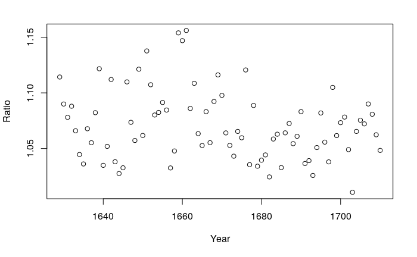

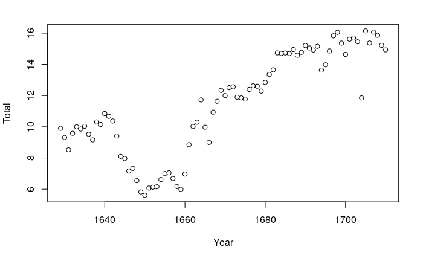

The `Total` is the total christenings in London (000s), so it should closely related toe the birth. We can see that `Total` is significant decreasing between 1640 to 1660, and then had a significant increasing between 1660 to 1680, and then maintained in a relative high level. This indicates that the population birth had a fluctuation between 1640 to 1680.

## Exercise 3.4

```r
# the ratio of chi_sq and df
chi_sq / 12
```

[output not shown]

So we can see that the ratio is relative high, this may incicates that this may not be a good fit. Actually we can calculate the p value fo the goodness of the fit test:

```r
pchisq(q = chi_sq, df = 12, lower.tail = FALSE)
```

```
[1] 2.013281e-46
```

This confirms the conclution.

The MLE of binominal distribution is $\hat{p} = x/n$, so we can calculate the $\hat{p}$.

```r
# goodness of fit test
summary(ml_fit)
```

```
Chi-squared approximation may be incorrect
```

```
     Goodness-of-fit test for binomial distribution

                      X^2 df     P(> X^2)
Pearson          110.5050 12 4.754460e-18
Likelihood Ratio  97.0065 12 2.143564e-15
```

Better than use $p = 1/2$, but p value is still low. But considering the sample size, it’s ok to have a low p value.

```r
# (c)
plot(binorm_fit)
plot(ml_fit)
```

[output not shown]